# Production Performance

5/9/2021

## Introduction

Hydraulic fracturing is a process applied to unconventional reservoirs to create artificial fractures connecting the pores where hydrocarbons are stored. The estimation of formation properties such as permeability and effective half fracture length is an important step in analyzing production performance.

## Methodology

1. Select the well for analysis from the drop-down menu
2. Select the end of the linear flow using the slider. The idea is to fit the blue line (linear model) as close as possible to straight line formed by the black dots. This is equivalent to estimate visually the end of linear flow (red line) and pass this value to the model
3. If necessary adjust the max value of Y using the slider
4. The estimated values will be shown at the bottom of the plot

Check the app: [Production Performance Shiny App](https://migueldb.shinyapps.io/production-performance/)

## Square Root of Time Plot

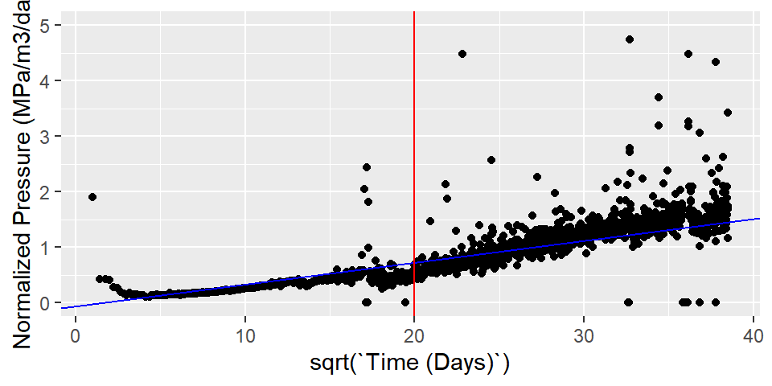

The permeability can be calculated using the limit of linear flow (red line) using the app.

```r
df <- wellDataSummary %>% filter(Lease == "EAGLE")
        d <- df %>% pull(`Spacing (m)`); phi <- df %>% pull(Porosity)
        mu <- df %>% pull(`Viscosity (mPa s)`); T_elf <- 20^2

        permeability(d = d, phi = phi, mu = mu, T_elf = T_elf)
```

```
## [1] 0.002784428
```

## References

- Dataset: SPE Data Repository: Data Set: 1, Well Number: all wells, From URL: https://www.spe.org/en/industry/data-repository/
- Luo, H., Li, H., Zhang, J. et al. Production performance analysis of fractured horizontal well in tight oil reservoir. J Petrol Explor Prod Technol 8, 229–247 (2018). https://doi.org/10.1007/s13202-017-0339-x
- https://github.com/migueldb/production-performance
- [Production Performance Shiny App](https://migueldb.shinyapps.io/production-performance/)